# IDA_HW9_Group66

987144, 987154 And 986384

January 22, 2020

# Exercise 1: Comparing two groups with a t-test

```r
group_1 <- c(
  104, 105, 100, 91, 105, 118, 164, 168, 111, 107, 136, 149, 104, 114, 107, 95,
  83, 114, 171, 176, 117, 107, 108, 107, 119, 126, 105, 119, 107, 131
)
group_2 <- c(
  133, 115, 84, 79, 127, 103, 109, 128, 127, 107, 94, 95, 90, 118, 124, 108,
  87, 111, 96, 89, 106, 121, 99, 86, 115, 136, 114
)

t.test(group_1,group_2, alternative = "two.sided", paired = FALSE)
```

```
##
##  Welch Two Sample t-test
##
## data:  group_1 and group_2
## t = 2.1325, df = 51.144, p-value = 0.03778
## alternative hypothesis: true difference in means is not equal to 0
## 95 percent confidence interval:
##   0.6739305 22.3038473
## sample estimates:
## mean of x mean of y
##  118.9333  107.4444
```

We conducted a T-test with group_1 and group_2 data and observed (t = 2.1325, p = 0.03778). The p-value is lesser than the significance level (0.05) so we can reject the claim that there is no difference between the two group.

# Exercise 2: Pearson’s $\chi^2$test of independence

```r
observed_counts <- matrix(
  c(
    31,56,23,
    104,67,12,
    24,34,42,
    19,16,8
  ),
  nrow = 4,
  byrow = T,
  dimnames = list(
    program = c("CogSci", "Psych", "Computer Science", "Philosophy"),
    preference = c("frequentist", "Bayes", "bootstrap")

  )
)

chisq.test(observed_counts)
```

```
##
##  Pearson's Chi-squared test
##
## data:  observed_counts
## X-squared = 69.473, df = 6, p-value = 5.243e-13
```

We conducted a Pearson’s $\chi^2$test observed (X-squared = 69.473, p-value = 5.243e-13). The p-value is lesser than the significance level (0.05) so we can reject the claim that there is no difference between the observed values of the 3 preferences among statistical tests.

# Exercise 3: Understanding a mystery function (8 points)

```r
mysterious_function <- function(vec) {
  map_lgl(
    1:(length(vec)-1),
    function(i) {vec[i] == vec[i+1]}
  ) %>% sum()
}
```

This function takes as input a vector and takes each value and check whether it is equal to the next value and adds up the number of times the consecutive items where same.

# Exercise 4: Simulating a p-value for a custom-made test statistic

## Binomial test of fairness

```r
binom.test(15,30,p = 0.5, alternative = "two.sided")
```

```
##
##  Exact binomial test
##
## data:  15 and 30
## number of successes = 15, number of trials = 30, p-value = 1
## alternative hypothesis: true probability of success is not equal to 0.5
## 95 percent confidence interval:
##  0.3129703 0.6870297
## sample estimates:
## probability of success
##                    0.5
```

We conducted a binomial test assuming that the coin is fair $\theta = 0.5$ and observed (N= 30, p = 1). The p-value is greater than the $\alpha$ so we will not be able to reject the null hypothesis claim that$\theta = 0.5$

## Questioning independence based on swaps

```r
obs_1 <- rep(c(1,0), each = 15)
obs_2 <- rep(c(1,0), times = 15)
obs_3 <- c(1,1,1,1,0,0,0,0,0,0,1,1,1,1,0,0,0,1,1,0,0,1,1,1,1,0,0,0,0,1)


number_of_swaps <- function(vec) {
  map_lgl(
    1:(length(vec)-1),
    function(i) {vec[i] != vec[i+1]}
  ) %>% sum()
}


number_of_swaps(obs_1)
```

```
## [1] 1
```

```r
number_of_swaps(obs_2)
```

```
## [1] 29
```

```r
number_of_swaps(obs_3)
```

```
## [1] 8
```

## Approximating a sampling distribution via sampling

```r
n_samples <- 100
sample_nr_swaps <- function(n_samples) {sample(c(1,0), size = 30, replace = T)}

swaps <- replicate(100000 ,number_of_swaps(sample_nr_swaps(n_samples)))
```

## Plot the sampling distribution

```r
count <- tibble(swaps)
count <- count %>% count(swaps)
count
```

```
## # A tibble: 24 x 2
##    swaps     n
##    <int> <int>
##  1     3     1
##  2     4     4
##  3     5    15
##  4     6   103
##  5     7   286
##  6     8   803
##  7     9  1904
##  8    10  3764
##  9    11  6515
## 10    12  9592
## # ... with 14 more rows
```

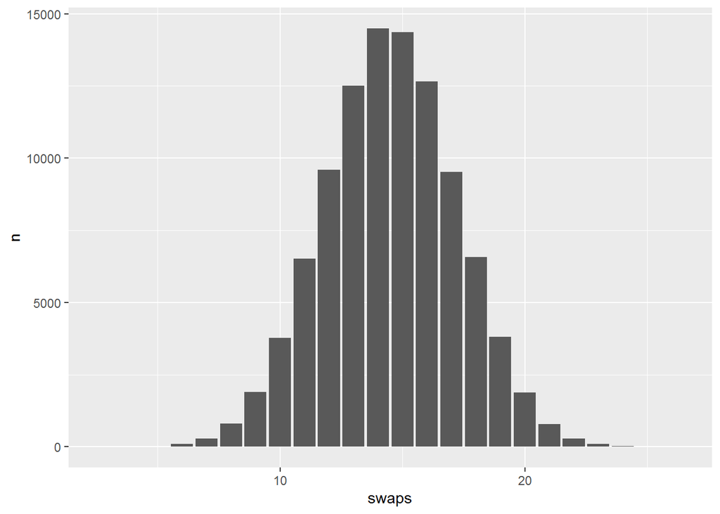

```r
ggplot(count, aes(x = swaps, y = n)) + geom_col()
```

## Compute a p-value with MC-sampling

```r
n_samples <- 100000
MC_sampling_p_value <- function(n_samples) {
  number_of_swaps(sample_nr_swaps(n_samples)* (1-number_of_swaps(obs_3)))/n_samples
}
MC_sampling_p_value(n_samples)
```

```
## [1] 0.00012
```